# Homework 1

Christopher Marais & Songzi Wu

2022-09-20

## Problem 1

### **1.1**

We imported the data and split the training, validation and test data.

```r
data_df <- read.csv("SML.NN.data.csv")
train_df = data_df[data_df$set == 'train',]
valid_df = data_df[data_df$set == 'valid',]
test_df = data_df[data_df$set == 'test',]
```

Thereafter we constructed the function to get the class probability for a single point estimated as the training data points within a radius from the point.

```r
# function to get proportion of class 1 in radius to point x (single)
# output is a float
getClass1Prop <- function(x, r, data=train_df) {
  "Import the data this function is
  based on before using it. The data should be named data_df
  and contain columns Y, X1, X2, set all in a dataframe.
  x is a vector of length 2
  r is the selected radius
  "
  # calculate the distance between the point and all the data
  x1 = (data$X1-as.numeric(x[1]))^2
  x2 = (data$X2-as.numeric(x[2]))^2
  data$euc_dist = sqrt(rowSums(data.frame(x1,x2)))
  #select points inside radius
  in_r_df = data[data$euc_dist <= r,]
  if(nrow(in_r_df)==0){
    # return NA if no points within radius
    return(NA)
  } else {
    # calculate proportion of class 1 values in data
    class_1_prop = sum(in_r_df$Y)/nrow(data)
    return(class_1_prop)
  }
}
```

### **1.2**

To create a function that calculates the miss clasification rates we first created a function that creates a classification based on the class 1 probability estimate produced from the previous function. The class 1 probability estimate can be done with the radius function given in 1.1 or with the K nearest neighbor function (KNN) given in 1.6. The method of choice is chosen based on the *func_type* parameter (“radius”=the radius based technique, “knn”= the nearest neighbors technique) . The *rk* parameter is used to allocate either radius size or number of neighbors based on the class 1 probability estimate technique used. The *t* parameter is used to specify the threshold at which the class probability estimate is seen as a positive class 1 classification. The *data* parameter is used to indicate which data set to use as training data.

```r
# get class 1 prediction for points in x (multiple)
# output is a vector of binary predictions
getClass1Prediction <- function(x, rk, t=0.5, data=train_df, func_type="radius"){
  "t is the threshold and should be between 0 and 1."
  pred_vec = c()
  # loop through all points in x
  for(i in 1:nrow(x)){
    x_i = x[c('X1','X2')][i,] # get coordinates
    if(func_type=="radius"){
      class_1_prop = getClass1Prop(x=x_i, r=rk, data=data)
    }else if(func_type=="knn") {
      class_1_prop = getClass1PropKNN(x=x_i, k=rk, data=data)
    }

    if(is.na(class_1_prop)){
      pred=NA
    }
    else if(class_1_prop >= t){
      pred=1
    }else{
      pred=0
    }
    pred_vec=c(pred_vec, pred)
  }
  return(pred_vec)
}
```

The function to calculate the miss classification was calculated as 1 - the proportion of correct classifications. This means that any classification that resulted in an NA or unknown was labelled as a miss classification.

```r
# function to get the miss classification rate
getMissClassRate <- function(true, pred){
  # make dataframe of predictions and true values
  df = data.frame(true, pred)
  # calculate equality of data
  df$equal = (df$true == df$pred)
  mis_class_rate = 1 - sum(df$equal, na.rm = TRUE)/nrow(df)
  return(mis_class_rate)
}
```

### **1.3**

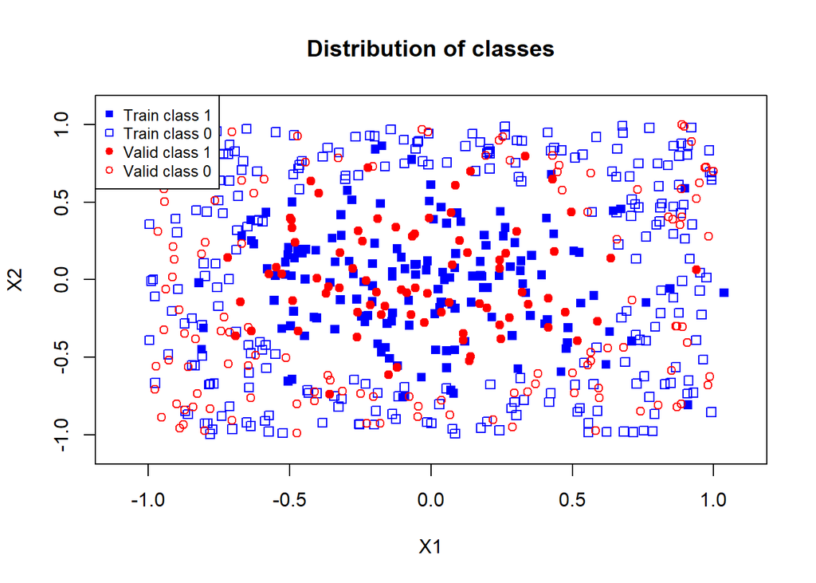

```r
# make plot of coordinates density distribution
plot(train_df[train_df$Y==1,]$X1,
     train_df[train_df$Y==1,]$X2,
     main = "Distribution of classes",
     xlab = "X1",
     xlim=c(-1.1, 1.1),
     ylab = "X2",
     ylim=c(-1.1, 1.1),
     pch = 15,
     col = "blue")
points(train_df[train_df$Y==0,]$X1, train_df[train_df$Y==0,]$X2, pch = 0, col = "blue")
points(valid_df[valid_df$Y==1,]$X1, valid_df[valid_df$Y==1,]$X2, pch = 19, col = "red")
points(valid_df[valid_df$Y==0,]$X1, valid_df[valid_df$Y==0,]$X2, pch = 1, col = "red")
legend("topleft",
       legend=c("Train class 1", "Train class 0", "Valid class 1", "Valid class 0"),
       col=c("blue","blue","red","red"),
       pch=c(15,0,19,1),
       cex=0.8)
```

### **1.4**

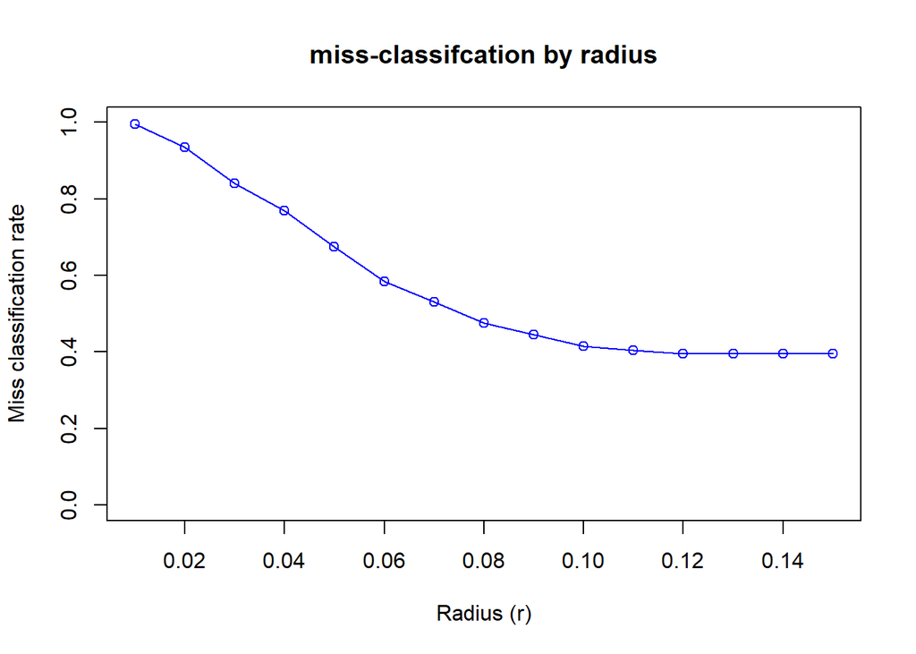

```r
# select best r for range of r values
# get class predictions
r_grid = seq(0.01, 0.15, 0.01)
class_pred_lst = lapply(r_grid,
                        getClass1Prediction,
                        x=valid_df,
                        t=0.5,
                        data=train_df,
                        func_type="radius")
# get miss classification rate
miss_class_lst = lapply(class_pred_lst, getMissClassRate, true = valid_df$Y)
# plot results
plot(x=r_grid,
      y=miss_class_lst,
      main="miss-classifcation by radius",
     xlab="Radius (r)",
     ylab="Miss classification rate",
     ylim=c(0,1),
     col="blue"
      )
lines(x=r_grid,
      y=miss_class_lst,
      col="blue")
```

From the plot we can see that the lowest r value is **0.12** with a miss classification rate of **0.395** for the validation data. This is not too far off from my guess of the radius of **0.1**.

```r
# get miss classification for test data with r*
getMissClassRate(true = test_df$Y,
                  pred = getClass1Prediction(
                    x=valid_df,
                    t=0.5,
                    rk=0.12,
                    data=train_df,
                    func_type="radius"
                  ))
```

```
## [1] 0.33
```

```r
# get miss classification for test data with guessed r
getMissClassRate(true = test_df$Y,
                  pred = getClass1Prediction(
                    x=valid_df,
                    t=0.5,
                    rk=0.1,
                    data=train_df,
                    func_type="radius"
                  ))
```

```
## [1] 0.365
```

### 1.5

We reduced the number of for loops to one. Which can be found in the *getClass1Prediction* function.